# Estimação

Fernando B. Sabino da Silva

# Estimação por ponto e por intervalo

## Estimação por ponto e por intervalo

- Nós queremos investigar hipóteses sobre parâmetros (constantes populacionais). Exemplo: a média $\mu$ e o desvio-padrão $\sigma$.
  - Se $\mu$ for o tempo médio de espera em uma fila, então pode ser relevante estudar se o tempo médio excede, por exemplo, a 2 minutos.
- Com base em uma amostra, nós calculamos uma **estimativa pontual** que de maneira coloquial é o nosso melhor “chute” para o valor do parâmetro.
  - Por exemplo, nós usamos $\bar{y}$ como uma estimativa para $\mu$ e $s$ como uma estimativa para $\sigma$.
- Em geral, nós estamos também interessados em calcular uma **estimativa por intervalo** (também chamada de **intervalo de confiança**). Este intervalo é construído em torno da estimativa por ponto.
- A estimativa do parâmetro (e o intervalo de confiança) pode ser utilizado para investigar a hipótese.

## Estimadores por ponto: Viés

- Se queremos estimar a média da população $\mu$, nós temos várias possibilidades (a princípio). Exemplos:
  - a média amostral $\bar{y}$
  - a média amostral $y_T$ dos quartis superior ($Q_{3}$) e inferior ($Q_{1}$).
- Vantagem de $y_T$: Pouca influência de outliers (observações com valor muito alto/baixo), i.e. não teremos praticamente nenhum efeito se houver alguns erros no banco de dados.
- Desvantagem de $y_T$: Se a distribuição da população for assimétrica, então $y_T$ será um estimador **viesado**, o que significa que no longo prazo este estimador sistematicamente será acima ou abaixo do verdadeiro valor de $\mu$.
- Geralmente, nós preferimos que um estimador seja **não viesado**, isto é, que a sua distriuição seja centrada em volta do verdadeiro valor do parâmetro.
- Relembre que para uma população com média $\mu$, a média amostral $\bar{y}$ também tem média $\mu$, i.e., $\bar{y}$ é um estimador não viesado da média populacional $\mu$.

## Estimadores por ponto: Eficiência

- Nós já sabemos (mostramos em aula - verifique se você sabe **provar** isto) que o erro padrão de $\bar{y}$ é $\frac{\sigma}{\sqrt{n}}$, i.e. o erro padrão converge para zero quando o tamanho da amostra aumenta (você saberia explicar a intuição disto?).
- É difícil expressar o erro padrão de $y_T$, mas é possível provar que ele será maior do que o erro padrão de $\bar{y}$. Este é um bom motivo para que, usualmente, $\bar{y}$ seja um estimador preferível.
- Em geral, nós preferimos que um estimador seja **eficiente**. De maneira coloquial, isto significa que o erro padrão converge para zero quando o tamanho da amostra aumenta. O estimador **mais eficiente** será aquele que converge para zero a uma velocidade maior. No nosso exemplo, para a maioria das populações, $y_T$ é ineficiente.

## Notação

- O símbolo $\hat{\ }$ acima de um parâmetro é frequentemente utilizado para denotar uma estimativa (pontual) de um parâmetro. Exemplos:
  - estimativa da média populacional: $\hat{\mu}=\bar{y}$
  - estimativa do desvio padrão: $\hat{\sigma}=s$
- Quando observamos uma variável binária ($0/1$), o que, por exemplo, é utilizada para denotar sim/não ou masculino/feminino, então nós usamos a notação
  $$p=P(Y=1)$$
  para a proporção da população com a característica $Y=1$.
- A estimativa $\hat{p}=(y_1+y_2+\ldots+y_n)/n$ é a frequência relativa amostral de $Y=1$.

## Intervalo de Confiança

- A definição geral de um intervalo de confiança para um parâmetro populacional é a seguinte:
  - Um **intervalo de confiança** para um parâmetro é um intervalo construído com base na amostra, isto é, ele é aleatório (depende da amostra em particular). Esperamos que este intervalo contenha o verdadeiro valor do parâmetro (que não é aleatório, é uma constante populacional).
  - A “probabilidade” de que esta construção produza um intervalo que inclua o verdadeiro valor do parâmetro é chamada de **nível de confiança** (ou de cobertura). Tipicamente, o nível de confiança escolhido é de $95\%$.
  - (1-nível de confiança) é chamado de **nível de significância** (neste exemplo, $1-0.95=0.05$, i.e. $5\%$).
- Frequentemente, o intervalo é construído como um intervalo simétrico em torno de uma estimativa por ponto:
  - **estimativa por ponto $\pm$margem de erro**
  - Regra de bolso: Com uma margem de erro de aproximadamente 1.96 vezes o erro padrão você obtém um intervalo de confiança de aproximadamente $95\%$.
  - i.e: **estimativa por ponto** $\pm$ **1.96 x erro padrão** tem nível de confiança de aproximadamente $95\%$.

## Intervalo de Confiança para a Proporção

- Considere uma população com uma distribuição onde a probabilidade de ter uma determinada característica seja $p$ e a probabilidade de não ter seja $1-p$.
- Quando as categorias $não/sim$ são denotadas por $0/1$, i.e. $y$ é $0$ ou $1$, a distribuição de $y$ tem um desvio padrão de :
  $$\quad \sigma=\sqrt{p(1-p)}.$$
  Isto é, o desvio padrão não é um parâmetro “livre” para uma variável $0/1$, pois o seu valor está diretamente ligado a probabilidade $p$.
- Com uma amostra de tamanho $n$ o erro padrão de $\hat{p}$ será (dado que $\hat{p} = \frac{\sum_{i=1}^n y_i}{n}$):
  $$\quad \sigma_{\hat{p}}=
  \frac{\sigma}{\sqrt{n}} =\sqrt{\frac{p(1-p)}{n}}.$$
- Nós não sabemos o valor de $p$, mas se inserirmos a estimativa iremos obter o **erro padrão estimado** de $\hat{p}$:
  $$ep=\sqrt{\frac{\hat{p}(1-\hat{p})}{n}}.$$
- A regra de bolso nos diz que o intervalo
  $$\hat{p}\pm 1.96\sqrt{\frac{\hat{p}(1-\hat{p})}{n}}$$
  tem nível de confiança de aproximadamente $95\%$. i.e., antes que os dados sejam conhecidos, o intervalo aleatório dado pela fórmula acima tem aproximadamente 95% de “probabilidade” de conter o verdadeiro valor de $p$.

### Exemplo: Estimativa por ponto e por intervalo para a proporção

- Vamos dar uma olhada em dados de uma pesquisa nacional conduzida no Chile entre Abril e Maio de 1988. Informações sobre os dados podem ser encontradas [aqui](https://www.rdocumentation.org/packages/car/versions/2.1-6/topics/Chile).

```r
Chile <- read.delim("C:/Users/fsabino/Desktop/Codes/papers/Introductory_Stat_II/notebook/Chile.txt")
```

- Concentremo-nos na variável `sex`, i.e. a distribuição de gênero na amostra.

```r
library(mosaic)
tally( ~ sex, data = Chile)
```

```
## sex
##    F    M
## 1379 1321
```

```r
tally( ~ sex, data = Chile, format = "prop")
```

```
## sex
##         F         M
## 0.5107407 0.4892593
```

### Exemple: Intervalos de confiança para a proporção no **R**

- **R** automaticamente calcula o intervalo de confiança para a proporção de pessoas do sexo feminino quando nós fazemos um teste de hipóteses (voltaremos a isso mais adiante):

```r
prop.test( ~ sex, data = Chile, correct = FALSE)
```

```
##
##  1-sample proportions test without continuity correction
##
## data:  Chile$sex  [with success = F]
## X-squared = 1.2459, df = 1, p-value = 0.2643
## alternative hypothesis: true p is not equal to 0.5
## 95 percent confidence interval:
##  0.4918835 0.5295675
## sample estimates:
##         p
## 0.5107407
```

- O argumento `correct = FALSE` é necessário para pedir ao **R** para fazer uma aproximação para a distribuição normal como feito nestas notas. Quando `correct = TRUE` (o default) uma correção matemática que você não aprendeu se aplica e os resultados serão ligeiramente diferentes.

## Intervalos de confiança aproximados para a proporção

- Com base no teorema central do limite (CLT), nós temos :
  $$\hat{p}\approx N \left (p,{\frac{p(1-p)}{n}} \right)$$
  **ep** $n\hat{p}$ e $n(1-\hat{p})$ são grandes o suficiente para que a aproximação seja válida (maiores do que $15$, por exemplo).
- Para construir um intervalo de confiança com nível de confiança (aproximado) $1-\alpha$:
  1. Encontre o valor crítico $z_{crit}$ para o qual a probabilidade na cauda superior da distribuição normal seja $\alpha/2$.
  2. Calcule $ep=\sqrt{\frac{\hat{p}(1-\hat{p})}{n}}$
  3. Então $\hat{p}\pm z_{crit}\times ep$ é um intervalo de confiança com nível de confiança $1-\alpha$.

### Exemplo: Dados do Chile

Para os dados do `Chile` calcule os intervalos de confiança 99% e 95% para a probabilidade de que uma pessoa seja do sexo feminino:

- Para um nível de confiança de $99\%$, temos $\alpha=1\%$ e
  1. $z_{crit}$=`qdist("norm", 1 - 0.01/2)`=2.576.
  2. Sabemos que $\hat{p}=0.5107$ e $n=2700$, então $ep = \sqrt{\frac{\hat{p}(1-\hat{p})}{n}} = 0.0096$.
  3. Assim, um intervalo de confiança de 99% é: $\hat{p}\pm z_{crit}\times ep=(0.4859, 0.5355)$.
- Para um nível de confiança de $95\%$, temos $\alpha=5\%$ e
  1. $z_{crit}$=`qdist("norm", 1 - 0.05/2)`=1.96.
  2. Novamente, $\hat{p}=0.5107$ and $n=2700$ e assim $ep=0.0096$.
  3. Deste modo, nós encontramos um intervalo de confiança de 95%: $\hat{p}\pm z_{crit}\times ep=(0.4918, 0.5295)$ (como resultado de `prop.test`).

## Intervalo de confiança para a média - amostra retirada de uma população com distribuição normal

- Quando é razoável supor que a distribuição da população é normal, nós temos o resultado **exato**
  $$\bar{y}\sim \texttt{N}\bigg(\mu,\frac{\sigma^{2}}{{n}}\bigg),$$
  i.e. $\bar{y}\pm z_{crit}\times \frac{\sigma}{\sqrt{n}}$ não é mais apenas um intervalo de confiança aproximado (como no caso da proporção - por que é aproximado neste caso?), mas sim um intervalo de confiança exato para a média populacional, $\mu$.
- Na prática, porém, **nós não conhecemos** $\sigma$ e ao invés disso, nós somos obrigados a utilizar o desvio padrão da amostra $s$ para encontrar o **erro padrão estimado** $ep=\frac{s}{\sqrt{n}}.$
- Esta incerteza extra, no entanto, implica que um intervalo de confiança exato para a média populacional $\mu$ não pode ser construído usando o escore-$z$.
- Um intervalo exato ainda pode ser construído usando o chamado **escore-$t$**, que além do nível de confiança depende dos **graus de liberdade** (degrees of freedom = df), que neste caso são $df = n-1$. Isto é, o intervalo de confiança toma agora a forma
  $$\bar{y}\pm t_{crit}\times ep.$$
- Nota: É importante aprender as relações entre as distribuições normal, t de Student, qui-quadrado e F. Veja mais detalhes em Costa Neto (Estatística) e Casella and Berger (Statistical Inference, traduzido para português). Mais detalhes serão vistos em sala de aula.

## A distribuição $t$ e o escore $t$

- O cálculo do escore $t$ é baseado na **distribuição $t$**, que é semelhante a distribuição normal padrão $z$:
  - ela é simétrica em torno de zero e é uma função em forma de “sino”, mas
  - como vimos tem caudas mais “pesadas” e portanto
  - um desvio padrão maior do que o desvio padrão da distribuição normal padrão.
  - Note que o desvio padrão da distribuição $t$ decaí em função de seus **graus de liberdade** (que denotamos por $df$).
  - e quando $df$ cresce a distribuição $t$ se aproxima da distribuição normal padrão.

A expressão da função densidade não será indicada aqui (pode ser encontrada nos livros sugeridos ou no google). Ao invés disso, a distribução $t$ é representada abaixo para $df =1,2,10$ e $\infty$.

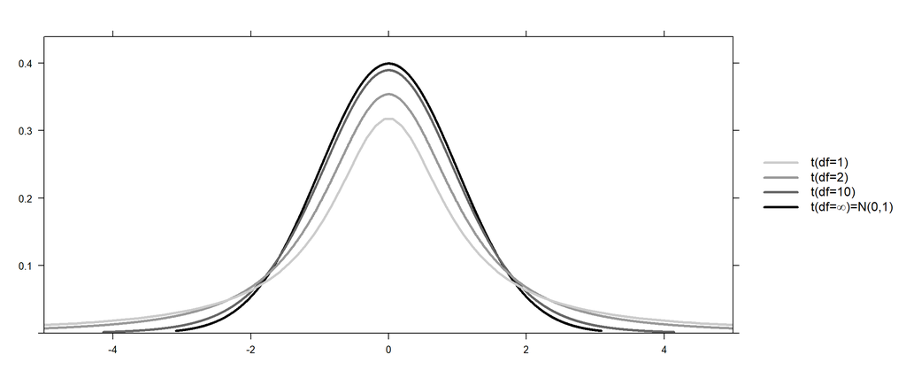

### Cálculo do escore $t$ no **R**

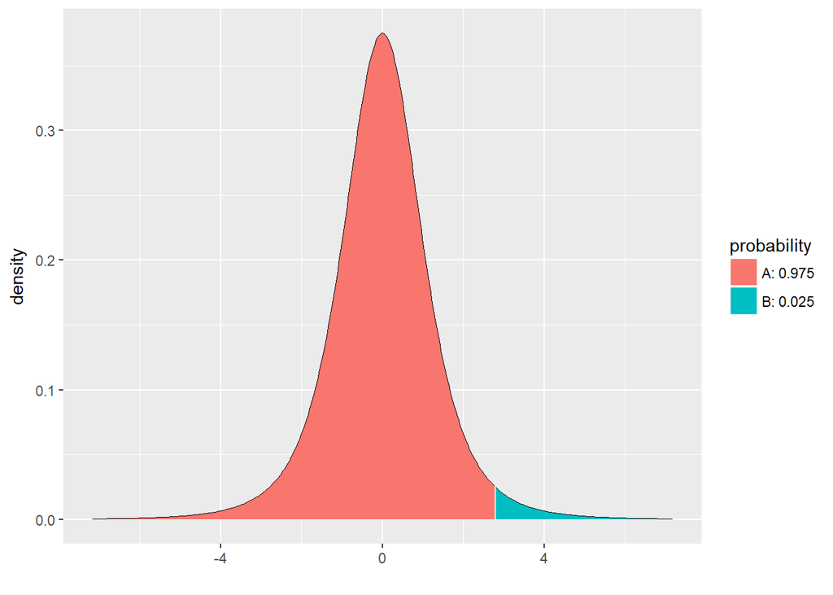

```
## [1] 2.776445
```

```r
qdist("t", p = 1 - 0.025, df = 4)
```

- Um escore $t$ é o quantil (i.e. o valor no eixo x) para o qual temos uma dada probabilidade na **cauda direita**.
- Para obter, por exemplo, um escore $t$ correspondente a uma probabilidade na cauda direita de 2.5 % nós temos que procurar o quantil 97.5 % usando `qdist` with `p = 1 - 0.025`, pois `qdist` olha a área para o **lado esquerdo**.
- Os graus de liberdade são determinados pelo tamanho da amostra. No exemplo anterior usamos df = 4 para ilustração.
- Como um escore $t$ para uma probabilidade na cauda direita de 2.5 % é 2.776 e a distribuição $t$ é simétrica em torno do 0, nós temos que uma observação tem probabilidade de 1 - 2 $\cdot$ 0.025 = 95 % de estar entre -2.776 and 2.776 para uma distribuição $t$ com 4 graus de liberdade.

## Exemplo: Intervalo de Confiança para a média

- Em estatística I usamos o conjunto de dados de `Ericksen`. Queremos agora construir um intervalo de confiança de $95\%$ para a média da população mean $\mu$ da variável `crime`.

```r
Ericksen <- read.delim("C:/Users/fsabino/Desktop/Codes/papers/Introductory_Stat_I/notebook/datasets_Ericksen.txt")
stats <- favstats( ~ crime, data = Ericksen)
stats
```

|  | min | Q1 | median | Q3 | max | mean | sd | n | missing |
| --- | --- | --- | --- | --- | --- | --- | --- | --- | --- |
|  | 25 | 48 | 55 | 73 | 143 | 63.06061 | 24.89107 | 66 | 0 |

```r
qdist("t", 1 - 0.025, df = 66 - 1, plot = FALSE)
```

```
## [1] 1.997138
```

- i.e., nós temos
  - $\bar{y} = 63.061$
  - $s = 24.891$
  - $n = 66$
  - $df = n-1 = 65$
  - $t_{crit} = 1.997$.
- O intervalo de confiança é $\bar{y}\pm t_{crit}\frac{s}{\sqrt{n}} = (56.94 , 69.18)$
- Todos estes cálculos podem ser feitos automaticamente no **R**:

```r
t.test( ~ crime, data = Ericksen, conf.level = 0.95)
```

```
##
##  One Sample t-test
##
## data:  crime
## t = 20.582, df = 65, p-value < 2.2e-16
## alternative hypothesis: true mean is not equal to 0
## 95 percent confidence interval:
##  56.94162 69.17960
## sample estimates:
## mean of x
##  63.06061
```

## Exemplo: Fazendo vários intervalos de confiança no **R**

- Vamos olhar o conjunto de dados `chickwts` que já vem integrado no **R**.
- `?chickwts` produz uma página com a seguinte informação

> Um experimento foi conduzido para medir e comparar a eficácia de vários suplementos alimentares sobre a taxa de crescimento de galinhas Os filhotes recém-nascidos foram alocados aleatoriamente em seis grupos, e cada grupo recebeu um suplemento alimeantar diferente. Seus pesos em gramas após seis semanas são dados juntamente com os tipos de alimentação.
- `chickwts` é um data frame com 71 observações e 2 variáveis:
  - `weight`: é uma variável numérica que representa o peso do filhote.
  - `feed`: um fator (variável qualitativa/categórica) que representa o tipo de alimentação.
- Calcule um intervalo de confiança para o peso médio de cada alimentação separadamente; o intervalo de confiança é de inferior(`lower`) para superior (`upper`) dado por média $\pm$ escore t * erro padrão (`mean`$\pm$`tscore * ep`):

```r
cwei <- favstats( weight ~ feed, data = chickwts)
ep <- cwei$sd / sqrt(cwei$n) # Erros padrão
tscore <- qdist("t", p = .975, df = cwei$n - 1, plot = FALSE) # Escores t para uma probabilidade de cada à direita de 2.5%
cwei$lower <- cwei$mean - tscore * ep
cwei$upper <- cwei$mean + tscore * ep
cwei[, c("feed", "mean", "lower", "upper")]
```

| feed | mean | lower | upper |
| --- | --- | --- | --- |
| casein | 323.5833 | 282.6440 | 364.5226 |
| horsebean | 160.2000 | 132.5687 | 187.8313 |
| linseed | 218.7500 | 185.5610 | 251.9390 |
| meatmeal | 276.9091 | 233.3083 | 320.5099 |
| soybean | 246.4286 | 215.1754 | 277.6818 |
| sunflower | 328.9167 | 297.8875 | 359.9458 |

- Nós podemos traçar os intervalos de confinaça como segmentos de linhas horizontais usando a função `gf_errorbarh`:

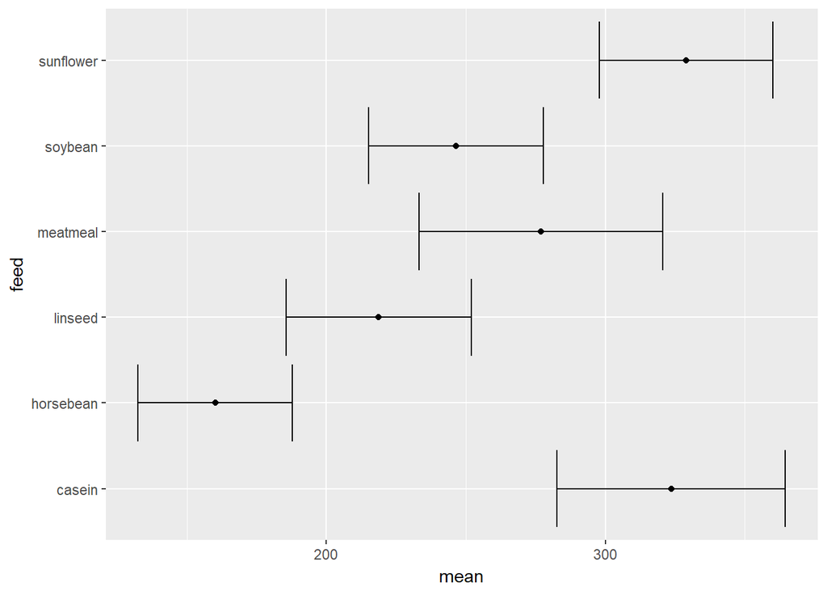

```r
gf_errorbarh(feed ~ mean + lower + upper, data = cwei) %>%
  gf_point(feed ~ mean)
```

# Determinando o tamanho da amostra

## Tamanho da amostra para a proporção

- O intervalo de confiança é da forma estimativa por ponto $\pm$ margem de erro estimada.
- Quando nós estimamos uma proporção, a margem de erro é
  $$e=z_{crit}\sqrt{\frac{p(1-p)}{n}},$$
  onde o escore $z$ crítico, $z_{crit}$, é determinado pelo nível de confiança especificado.
- Imagine que nós queremos planejar um experimento, onde **desejamos obter uma certa margem de erro $e$** (e portanto uma largura específica do intervalo de confiança associado).
- Se nós resolvermos a equação acima, é possível notar:
  - Se $n=p(1-p)(\frac{z_{crit}}{e})^2$, nós obtemos uma estimativa de $p$ com margem de erro $e$.
- Se não tivermos um bom palpite para o valor de $p$, nós podemos usar o valor do “pior” caso, isto é, $p=50\%$ ($1/4$ é o maior valor possível que pode assumir a função $p(1-p)$). O tamanho amostral correspondente $n=(\frac{z_{crit}}{2e})^2$ garante que nós iremos obter uma estimativa com uma margem de erro que é no *máximo* $e$.

### Exemplo

- Vamos escolher $z_{crit}=1.96$, i.e o nível de confiança é de 95%.
- Qual o número de eleitores que devemos entrevistar para obter uma margem de erro igual a $1\%$?
- O pior caso é $p=0.5$, o que nos leva a:
  $$n=p(1-p)\left(\frac{z_{crit}}{e}\right)^2=\frac{1}{4}\left(\frac{1.96}{0.01}\right)^2 = 9604.$$
- Se nós estivermos interessados na proporção de votos para o candidato de um partido cujo um bom palpite é de no máximo $p=0.23$, teríamos
  $$n=p(1-p)\left(\frac{z_{crit}}{e}\right)^2=0.23(1-0.23)\left(\frac{1.96}{0.01}\right)^2 = 6804.$$
- Se nós estivermos interessados na proporção de votos para o candidato de um partido cujo um bom palpite é de no máximo $p=0.05$, teríamos
  $$n=p(1-p)\left(\frac{z_{crit}}{e}\right)^2 = 0.05(1-0.05)\left(\frac{1.96}{0.01}\right)^2 = 1825.$$

## Tamanho da amostra para a média

- O intervalo de confiança é da forma estimativa por ponto $\pm$ margem de erro estimada.
- Quando estimamos uma média com desvio-padrão conhecido a margem de erro é
  $$e=z_{crit}\frac{\sigma}{\sqrt{n}},$$
  onde um escore $z$ crítico, $z_{crit}$, é determinado pelo nível especificado de confiança.
- Imagine que nós queremos planejar um experimento, onde **desejamos obter uma certa margem de erro $e$**.
- Se nós resolvermos a equação acima, é possível notar:
  - Se $n=(\frac{z_{crit}\sigma}{e})^2$, nós obtemos uma estimativa com margem de erro $e$.
- Problema: Nós usualmente não sabemos $\sigma$. Possíveis soluções:
  - Com base em estudos similares realizados anteriormente, nós fazemos um palpite “educado” sobre o valor de $\sigma$.
  - Baseado em um estudo piloto estimamos o valor de $\sigma$.

# Exercícios e Leituras Recomendadadas

$1$. Qual deve ser o valor do desvio padrão para que uma distribuição normal com média 9 cubra o intervalo 0-18 com probabilidade de 99.73%? Experimente com diferentes valores de $n$.

$2$. Leia a seção 3.4 de Costa Neto (doravante CN) e verifique o que foi dado em aula sobre o assunto.

$3$. Leia as seções 4.4 e 4.5 de CN e refaça os exemplos (tem solução).

$4$. Faça os exercícios 1, 3, 5, 7, 14, 16, 17, 18 e 21 da seção 4.6 (Exercícios propostos) de CN.

# Apêndice

- Instale o pacote TeachingDemos: install.packages(“TeachingDemos”). Após a instalação carregue o pacote para poder usá-lo: library(TeachingDemos).
- Use a função ci.examp() para visualizar 50 intervalos de confiança. Você pode visualizar os argumentos usados (by default) na função pedindo ajuda: ?ci.examp
- Tente alterar alguns dos argumentos da função e utilize method = “t”. Experimente, por exemplo, gerar 40 amostras aleatórias (reps = 40) e “depois peça os gráficos correspondentes com”plote" os correspondentes 40 intervalos de confiança usando um nível de confiança de 90% (conf.level = 0.90).
- Convença-se de que esperamos que 4 destes intervalos de confiança não contenham a verdadeira média populacional. Como isso se encaixa com o que você está vendo?
- Visualize melhor usando o seguinte aplicativo: http://shiny.calvin.edu/rpruim/CIs/
- Experimente também a função clt.examp(). Visualize os argumentos pedindo ajuda: ?clt.examp
- Use a função windows() para abrir um dispositivo gráfico.
  - clt.examp()
  - clt.examp(5)
  - clt.examp(30)
  - clt.examp(50)